# S1_dataclean_ABCD

2024-08-04

## Step1 Include TD or ADHD

This study included children with either ADHD or TD diagnosis.

ksads-comp attention-deficit/hyperactivity disorder Present = 1 (ksads_14_853_p, ksads2_14_809_p), or attention-deficit/hyperactivity disorder in partial remission = 1 (ksads_14_855_p, ksads2_14_811_p), or Other Specified Attention-Deficit/Hyperactivity Disorder (F90.8) = 1 (ksads2_14_813_p), or unspecified attention-deficit/hyperactivity disorder (F90.9) = 1 (ksads_14_856_p).

All the “partial remission”, “other specified”, and “unspecified” reflected not meet the full criteria for ADHD currently.

Participants with none of 173 types of mental disease will be identified as TD based on parents’ reports. Regardless of present or past.

The following codes are used for symptoms and diagnoses in the KSADS:

1 = present 0 = absent 888 = Question not asked due to primary question response (branching logic) 555 = Not administered in the assessment

```r
## 1. Diagnosed as TD or ADHD
mh_p_ksads2 <- read.csv(paste0(infopath, "/mh_p_ksads_lab2.csv"))
mh_p_ksads2[,c("src_subject_id", "eventname")] <- NULL
ADHD_l_commor <- read.csv(paste0(infopath, "/ADHD_l_commorbidityexclude.csv"))

demo_sublist0 <- mh_p_ksads2 %>% filter(if_TD ==1 | if_ADHD == T)
demo_sublist0 <- demo_sublist0 %>% filter(eventname2 %in% c("baselineYear1Arm1", "2YearFollowUpYArm1", "4YearFollowUpYArm1"))

# Add commorbidity information
demo_sublist0 <- demo_sublist0 %>% left_join(select(ADHD_l_commor, scanID, exclude_commorbid1, exclude_commorbid2), by="scanID")

tab <- table(demo_sublist0$if_TD, demo_sublist0$eventname2)

for (i in 1){
  print(paste("1st, from baseline, we included", tab[1,3], "ADHD children, and", tab[2,3], "TD children."))
  print(paste("from 2year FU, we included", tab[1,1], "ADHD children, and", tab[2,1], "TD children."))
  print(paste("from 4year FU, we included", tab[1,2], "ADHD children, and", tab[2,2], "TD children."))
}
```

```
## [1] "1st, from baseline, we included 1062 ADHD children, and 4613 TD children."
## [1] "from 2year FU, we included 727 ADHD children, and 4862 TD children."
## [1] "from 4year FU, we included 398 ADHD children, and 2675 TD children."
```

## Step2 general exclusion by demographic information

We will keep participants from baseline, 2year-follow up, and 4year-follow up. Exclusion criteria: 1)Participants were not proficient in English; 2)Parents were not proficient in English or Spanish; 3)Participants with traumatic brain injury history (Mild, moderate, and severe); 4)Participants with uncorrected visual or auditory deficits; 5)Participants with intellectual disability; 6)Participants with major medical or neurological conditions; 7)Participants with MRI contraindications.

```r
demo_sublist_criteria <- read.csv(paste0(infopath, "/demo_sublist_criteria.csv"))
demo_sublist_criteria <- demo_sublist_criteria %>%
  filter(eventname %in% c("baseline_year_1_arm_1", "2_year_follow_up_y_arm_1", "4_year_follow_up_y_arm_1"))

demo_sublist0 <- demo_sublist0 %>% left_join(demo_sublist_criteria, by="scanID")

demo_sublist <- demo_sublist0 %>%
  filter(if_language_y==F &
         if_language_p==F &
         if_TBI==F &
         if_sensory==F &
         if_intel==F &
         if_medical==F &
         if_contra==F &
         if_age==F &
         if_gender==F)

num_exclude1_base <- sum(demo_sublist0$eventname2=="baselineYear1Arm1") - sum(demo_sublist$eventname=="baseline_year_1_arm_1")
num_exclude1_2year <- sum(demo_sublist0$eventname2=="2YearFollowUpYArm1") - sum(demo_sublist$eventname=="2_year_follow_up_y_arm_1")
num_exclude1_4year <- sum(demo_sublist0$eventname2=="4YearFollowUpYArm1") - sum(demo_sublist$eventname=="4_year_follow_up_y_arm_1")
num_exclude1 = num_exclude1_base+num_exclude1_2year+num_exclude1_4year

tab <- table(demo_sublist$if_TD, demo_sublist$eventname2)

for (i in 1){
  print(paste("2nd, based on demographic criteria, we excluded", num_exclude1, "visits in total,", num_exclude1_base, "from baseline,", num_exclude1_2year, "from 2year,", num_exclude1_4year, "from 4year."))
table(demo_sublist$eventname)
  print(paste("from baseline, we included", tab[1,3], "ADHD children, and", tab[2,3], "TD children."))
  print(paste("from 2year FU, we included", tab[1,1], "ADHD children, and", tab[2,1], "TD children."))
  print(paste("from 4year FU, we included", tab[1,2], "ADHD children, and", tab[2,2], "TD children."))
}
```

```
## [1] "2nd, based on demographic criteria, we excluded 743 visits in total, 326 from baseline, 241 from 2year, 176 from 4year."
## [1] "from baseline, we included 991 ADHD children, and 4358 TD children."
## [1] "from 2year FU, we included 694 ADHD children, and 4654 TD children."
## [1] "from 4year FU, we included 386 ADHD children, and 2511 TD children."
```

## Step3 MRI & commorbidity

1. participants with complete MRI data from 3 visits.
2. successfully converted to BIDS.
3. passed official QC.
4. without commorbidity of schizophrenia (present or past), major depression (present), substance abuse.

```r
demo_sublist$eventname2 <- gsub("_(.)", "\\U\\1", demo_sublist$eventname, perl = T)
table(demo_sublist$eventname2)
```

```
##
## 2YearFollowUpYArm1 4YearFollowUpYArm1  baselineYear1Arm1
##               5348               2897               5349
```

```r
demo_sublist$scanID <- paste0(gsub("NDAR_", "sub-NDAR", demo_sublist$src_subject_id),"_ses-", demo_sublist$eventname2)
demo_sublist <- demo_sublist %>% select(c(names(demo_sublist)[! str_detect(names(demo_sublist), "if_")], "if_ADHD", "if_TD"))
# rbind filerecords
filerecord_base$scanID <- paste0(gsub("NDAR_", "sub-NDAR", filerecord_base$src_subject_id),"_ses-", filerecord_base$eventname2)
filerecord_2year$scanID <- paste0(gsub("NDAR_", "sub-NDAR", filerecord_2year$src_subject_id),"_ses-", filerecord_2year$eventname2)
filerecord_4year$scanID <- paste0(gsub("NDAR_", "sub-NDAR", filerecord_4year$src_subject_id),"_ses-", filerecord_4year$eventname2)
ncol4year <- ncol(filerecord_4year)
filerecord_4year <- cbind(filerecord_4year, data.frame(matrix(NA, nrow(filerecord_4year), ncol(filerecord_2year)-ncol(filerecord_4year))))
names(filerecord_4year)[(ncol4year+1):ncol(filerecord_2year)] <- setdiff(names(filerecord_2year), names(filerecord_4year)[1:ncol4year])
filerecord_all <- rbind(filerecord_base, filerecord_2year, filerecord_4year)
filerecord_all[,c("src_subject_id", "eventname2", "eventname")] <- NULL
demo_sublist <- merge(demo_sublist, filerecord_all, by="scanID", all.x = T)

## 1. complete raw data
demo_sublist2 <- demo_sublist %>% filter(dMRI_size>0 & T1WI_size>0 & fmap_size>0)
# Philips dMRI with less than 102 gradients
index_P_incomplete <- which(demo_sublist2$scanner=="Philips" & demo_sublist2$philips_gradientnum<102)
demo_sublist2 <- demo_sublist2[-index_P_incomplete, ]
num_exclude2_base <- nrow(demo_sublist[demo_sublist$eventname2=="baselineYear1Arm1",]) - nrow(demo_sublist2[demo_sublist2$eventname2=="baselineYear1Arm1",])
num_exclude2_2year <- nrow(demo_sublist[demo_sublist$eventname2=="2YearFollowUpYArm1",]) - nrow(demo_sublist2[demo_sublist2$eventname2=="2YearFollowUpYArm1",])
num_exclude2_4year <- nrow(demo_sublist[demo_sublist$eventname2=="4YearFollowUpYArm1",]) - nrow(demo_sublist2[demo_sublist2$eventname2=="4YearFollowUpYArm1",])

tab <- table(demo_sublist2$if_TD, demo_sublist2$eventname2)

for (i in 1){
  print(paste("3rd,", nrow(demo_sublist2), "have complete MRI data via fasttrack,", num_exclude2_base, "participants were excluded from baseline,", num_exclude2_2year, "participants were excluded from 2year-follow-up,", num_exclude2_4year, "participants were excluded from 4year-follow-up."))
  print(paste("from baseline, we included", tab[1,3], "ADHD children, and", tab[2,3], "TD children."))
  print(paste("from 2year FU, we included", tab[1,1], "ADHD children, and", tab[2,1], "TD children."))
  print(paste("from 4year FU, we included", tab[1,2], "ADHD children, and", tab[2,2], "TD children."))
}
```

```
## [1] "3rd, 8708 have complete MRI data via fasttrack, 1064 participants were excluded from baseline, 1735 participants were excluded from 2year-follow-up, 2087 participants were excluded from 4year-follow-up."
## [1] "from baseline, we included 757 ADHD children, and 3528 TD children."
## [1] "from 2year FU, we included 499 ADHD children, and 3114 TD children."
## [1] "from 4year FU, we included 123 ADHD children, and 687 TD children."
```

```r
## 2. successful unzip & dcm2nii
demo_sublist3 <- demo_sublist2 %>% filter(if_bids==T)
num_exclude3_base <- nrow(demo_sublist2[demo_sublist2$eventname2=="baselineYear1Arm1",]) - nrow(demo_sublist3[demo_sublist3$eventname2=="baselineYear1Arm1",])
num_exclude3_2year <- nrow(demo_sublist2[demo_sublist2$eventname2=="2YearFollowUpYArm1",]) - nrow(demo_sublist3[demo_sublist3$eventname2=="2YearFollowUpYArm1",])
num_exclude3_4year <- nrow(demo_sublist2[demo_sublist2$eventname2=="4YearFollowUpYArm1",]) - nrow(demo_sublist3[demo_sublist3$eventname2=="4YearFollowUpYArm1",])

print(paste("4th,", nrow(demo_sublist3), "have been successfully converted to BIDS,", num_exclude3_base, "participants from baseline,", num_exclude3_2year, "participants from 2year-follow-up,", num_exclude3_4year,"participants from 4year-follow-up", "failed unzip or dcm2niix."))
```

```
## [1] "4th, 8537 have been successfully converted to BIDS, 104 participants from baseline, 64 participants from 2year-follow-up, 3 participants from 4year-follow-up failed unzip or dcm2niix."
```

```r
## 3. passed official QC
mri_y_qc_incl <- read.csv(paste0(release5path, "/imaging/mri_y_qc_incl.csv"))
demo_sublist4 <- merge(demo_sublist3, mri_y_qc_incl, by=c("src_subject_id", "eventname"), all.x=T)
demo_sublist4 <- demo_sublist4 %>% filter(imgincl_t1w_include==1 & imgincl_dmri_include==1)

num_exclude4_base <- nrow(demo_sublist3[demo_sublist3$eventname2=="baselineYear1Arm1",]) - nrow(demo_sublist4[demo_sublist4$eventname2=="baselineYear1Arm1",])
num_exclude4_2year <- nrow(demo_sublist3[demo_sublist3$eventname2=="2YearFollowUpYArm1",]) - nrow(demo_sublist4[demo_sublist4$eventname2=="2YearFollowUpYArm1",])
num_exclude4_4year <- nrow(demo_sublist3[demo_sublist3$eventname2=="4YearFollowUpYArm1",]) - nrow(demo_sublist4[demo_sublist4$eventname2=="4YearFollowUpYArm1",])

tab <- table(demo_sublist4$if_TD, demo_sublist4$eventname2)

for (i in 1){
  print(paste("5th,", nrow(demo_sublist4), "passed official QC,", num_exclude4_base, "participants from baseline,", num_exclude4_2year, "participants from 2year-follow-up,",num_exclude4_4year, "participants from 4year-follow-up were excluded due to low imaging quality."))
  print(paste("from baseline, we included", tab[1,3], "ADHD children, and", tab[2,3], "TD children."))
  print(paste("from 2year FU, we included", tab[1,1], "ADHD children, and", tab[2,1], "TD children."))
  print(paste("from 4year FU, we included", tab[1,2], "ADHD children, and", tab[2,2], "TD children."))
}
```

```
## [1] "5th, 8082 passed official QC, 280 participants from baseline, 152 participants from 2year-follow-up, 23 participants from 4year-follow-up were excluded due to low imaging quality."
## [1] "from baseline, we included 669 ADHD children, and 3232 TD children."
## [1] "from 2year FU, we included 446 ADHD children, and 2951 TD children."
## [1] "from 4year FU, we included 119 ADHD children, and 665 TD children."
```

```r
# 4. finish preprocessing
demo_sublist_unfinished <- demo_sublist4 %>% filter(qsiprep_finished==0 | schaefer400_7_num != 452)
demo_sublist_finished <- demo_sublist4 %>% filter(qsiprep_finished==T)
demo_sublist5_list <- demo_sublist4[,c("src_subject_id", "eventname2", "siteID", "scanner")]
write.csv(demo_sublist5_list, paste0(infopath, "/demo_sublist5_list.csv"), row.names = F)
write.csv(demo_sublist4, paste0(infopath, "/demo_sublist4.csv"), row.names = F)

num_exclude5_base <- sum(demo_sublist4$eventname2=="baselineYear1Arm1") - sum(demo_sublist_finished$eventname=="baseline_year_1_arm_1")
num_exclude5_2year <- sum(demo_sublist4$eventname2=="2YearFollowUpYArm1") - sum(demo_sublist_finished$eventname=="2_year_follow_up_y_arm_1")
num_exclude5_4year <- sum(demo_sublist4$eventname2=="4YearFollowUpYArm1") - sum(demo_sublist_finished$eventname=="4_year_follow_up_y_arm_1")
num_exclude5 = num_exclude5_base+num_exclude5_2year+num_exclude5_4year

tab <- table(demo_sublist_finished$if_TD, demo_sublist_finished$eventname2)

for (i in 1){
  print(paste("6th,", num_exclude5, "visits in total,", num_exclude5_base, "from baseline,", num_exclude5_2year, "from 2year,", num_exclude5_4year, "from 4year failed SC reconstruction."))
  print(paste("from baseline, we included", tab[1,3], "ADHD children, and", tab[2,3], "TD children."))
  print(paste("from 2year FU, we included", tab[1,1], "ADHD children, and", tab[2,1], "TD children."))
  print(paste("from 4year FU, we included", tab[1,2], "ADHD children, and", tab[2,2], "TD children."))
}
```

```
## [1] "6th, 35 visits in total, 9 from baseline, 18 from 2year, 8 from 4year failed SC reconstruction."
## [1] "from baseline, we included 665 ADHD children, and 3227 TD children."
## [1] "from 2year FU, we included 446 ADHD children, and 2933 TD children."
## [1] "from 4year FU, we included 117 ADHD children, and 659 TD children."
```

```r
# 5. exclude commorbidity: set2 Schizophrenia, Major Depressive Disorder Present, Substance abuse
demo_sublist5 <- demo_sublist_finished %>% filter(is.na(exclude_commorbid2) | exclude_commorbid2==F)

num_exclude6_base <- sum(demo_sublist_finished$eventname2=="baselineYear1Arm1") - sum(demo_sublist5$eventname=="baseline_year_1_arm_1")
num_exclude6_2year <- sum(demo_sublist_finished$eventname2=="2YearFollowUpYArm1") - sum(demo_sublist5$eventname=="2_year_follow_up_y_arm_1")
num_exclude6_4year <- sum(demo_sublist_finished$eventname2=="4YearFollowUpYArm1") - sum(demo_sublist5$eventname=="4_year_follow_up_y_arm_1")
num_exclude6 = num_exclude6_base+num_exclude6_2year+num_exclude6_4year

tab <- table(demo_sublist5$if_TD, demo_sublist5$eventname2)

for (i in 1){
  print(paste("7th, based on commorbidity,", num_exclude6, "visits in total,", num_exclude6_base, "from baseline,", num_exclude6_2year, "from 2year,", num_exclude6_4year, "from 4year."))
  print(paste("from baseline, we included", tab[1,3], "ADHD children, and", tab[2,3], "TD children."))
  print(paste("from 2year FU, we included", tab[1,1], "ADHD children, and", tab[2,1], "TD children."))
  print(paste("from 4year FU, we included", tab[1,2], "ADHD children, and", tab[2,2], "TD children."))
}
```

```
## [1] "7th, based on commorbidity, 77 visits in total, 43 from baseline, 33 from 2year, 1 from 4year."
## [1] "from baseline, we included 622 ADHD children, and 3227 TD children."
## [1] "from 2year FU, we included 413 ADHD children, and 2933 TD children."
## [1] "from 4year FU, we included 116 ADHD children, and 659 TD children."
```

```r
# 6. head motion
demo_sublist6 <- demo_sublist5 %>% filter(meanFD<mean(meanFD,na.rm = T)+3*sd(meanFD,na.rm = T))

num_exclude7_base <- sum(demo_sublist5$eventname2=="baselineYear1Arm1") - sum(demo_sublist6$eventname=="baseline_year_1_arm_1")
num_exclude7_2year <- sum(demo_sublist5$eventname2=="2YearFollowUpYArm1") - sum(demo_sublist6$eventname=="2_year_follow_up_y_arm_1")
num_exclude7_4year <- sum(demo_sublist5$eventname2=="4YearFollowUpYArm1") - sum(demo_sublist6$eventname=="4_year_follow_up_y_arm_1")
num_exclude7 = num_exclude7_base+num_exclude7_2year+num_exclude7_4year

tab <- table(demo_sublist6$if_TD, demo_sublist6$eventname2)

for (i in 1){
  print(paste("8th, due to exaggerated head motion,", num_exclude7, "visits in total,", num_exclude7_base, "from baseline,", num_exclude7_2year, "from 2year,", num_exclude7_4year, "from 4year."))
  print(paste("from baseline, we included", tab[1,3], "ADHD children, and", tab[2,3], "TD children."))
  print(paste("from 2year FU, we included", tab[1,1], "ADHD children, and", tab[2,1], "TD children."))
  print(paste("from 4year FU, we included", tab[1,2], "ADHD children, and", tab[2,2], "TD children."))
}
```

```
## [1] "8th, due to exaggerated head motion, 131 visits in total, 75 from baseline, 55 from 2year, 1 from 4year."
## [1] "from baseline, we included 600 ADHD children, and 3174 TD children."
## [1] "from 2year FU, we included 401 ADHD children, and 2890 TD children."
## [1] "from 4year FU, we included 116 ADHD children, and 658 TD children."
```

## Step3 merge demographic information

```r
demo_sublist6 <- demo_sublist6 %>% select(!(contains("size") | contains("num") | contains("include") | contains("nii")))
demo_sublist6$siteID_r <- demo_sublist6$scanner_manufacturer_pd <- NULL

# age & sex
abcd_p_demo <- read.csv(paste0(release5path,'/abcd-general/abcd_p_demo.csv'))
demo_sublist6$age <- demo_sublist6$interview_age / 12
demo_sublist6 <- demo_sublist6 %>% left_join(select(abcd_p_demo, c("src_subject_id", "demo_sex_v2")), by="src_subject_id", multiple="first")

# handedness
nc_y_ehis <- read.csv(paste0(release5path, '/neurocognition/nc_y_ehis.csv'))
demo_sublist6 <- demo_sublist6 %>% left_join(select(nc_y_ehis, c("src_subject_id", "ehi_y_ss_scoreb")), join_by("src_subject_id"), multiple="first")


# cognition
nc_y_nihtb <- read.csv(paste0(release5path, '/neurocognition/nc_y_nihtb.csv'))
interest_cogvar <- c("src_subject_id", "eventname","nihtbx_flanker_uncorrected", "nihtbx_list_uncorrected", "nihtbx_cardsort_uncorrected", "nihtbx_pattern_uncorrected", "nihtbx_fluidcomp_uncorrected", "nihtbx_cryst_uncorrected", "nihtbx_totalcomp_uncorrected")
demo_sublist6 <- demo_sublist6 %>% left_join(select(nc_y_nihtb, all_of(interest_cogvar)), by=join_by(src_subject_id, eventname))

# merge pfactor
pFactor <- read.csv(paste0(infopath,"/p.factor/BifactorP_baseTo4Year.csv"))
pFactor$eventname2 <- gsub("_", "", pFactor$eventname)
pFactor$eventname <- NULL
demo_sublist7 <- merge(demo_sublist6, pFactor, by.x=c("src_subject_id", "eventname2"), by.y=c("srcsubjectid", "eventname2"), all.x=T)

# merge ADHD 2 dimension
ADHD2dim <- read.csv(paste0(infopath,"/ADHDsymptomDim/ADHD2dim_baseTo4Year.csv"))
ADHD2dim$eventname2 <- gsub("_", "", ADHD2dim$eventname)
ADHD2dim$eventname <- NULL
demo_sublist7 <- merge(demo_sublist7, ADHD2dim, by.x=c("src_subject_id", "eventname2"), by.y=c("srcsubjectid", "eventname2"), all.x=T)

# CBCL
mh_p_cbcl <- read.csv(paste0(release5path, "/mental-health/mh_p_cbcl.csv"))
mh_p_cbcl <- mh_p_cbcl %>% select(c("src_subject_id", "eventname", ends_with("_r"), ends_with("_t")))
demo_sublist7 <- merge(demo_sublist7, mh_p_cbcl, by=c("src_subject_id", "eventname"), all.x=T)


# SES
abcd_p_demo <- read.csv(paste0(release5path,'/abcd-general/abcd_p_demo.csv'))
demo_sublist7 <- demo_sublist7 %>% left_join(select(abcd_p_demo, c("src_subject_id", "eventname", "demo_comb_income_v2", "demo_roster_v2", "demo_comb_income_v2_l", "demo_roster_v2_l")), join_by("src_subject_id", "eventname"))
demo_sublist7 <- demo_sublist7 %>%
  group_by(src_subject_id) %>%
  mutate(demo_comb_income_v2 = coalesce(demo_comb_income_v2, demo_comb_income_v2_l)) %>%
  mutate(demo_roster_v2 = coalesce(demo_roster_v2, demo_roster_v2_l)) %>%
  ungroup()
demo_sublist7$demo_comb_income_v2_l <- demo_sublist7$demo_roster_v2_l <- NULL
demo_sublist7$totalincome <- dplyr::recode(demo_sublist7$demo_comb_income_v2,
                                      `1` = 2500, `2` = 8500, `3` = 13999.5, `4` = 20499.5, `5` = 29999.5, `6` = 42499.5, `7` = 62499.5, `8` = 87499.5, `9` = 149999.5, `10` = 200000)
demo_sublist7$interviewYear<-substr(demo_sublist7$interview_date,start=nchar(demo_sublist7$interview_date)-3, stop=nchar(demo_sublist7$interview_date))
demo_sublist7$interviewYear=as.numeric(demo_sublist7$interviewYear)
reference_data <- data.frame(familysize = rep(c(1:12),7),
                             povertyline = c(11880,16020,20160,24300,28440,32580,36730,40890,seq(from=45050, to=(45050+4160*3), by=4160), 12140,16460,20780,25100,29420,33740,38060,42380, 46700,51020, 55340,  59660, 12060,16240,20420,24600,28780,32960,37140,41320, 45500,  49680,  53860,  58040,12490,    16910,  21330,  25750,  30170,  34590,  39010,  43430,  47850,  52270,  56690,  61110,seq(from=12760, to=(12760+4480*11), by=4480), seq(from=12880, to=(12880+4540*11), by=4540), seq(from=12880, to=(13590+4720*11), by=4720)),Year = c(rep(2016,12),rep(2018,12), rep(2017,12), rep(2019,12),rep(2020,12),rep(2021,12),rep(2022,12)))
demo_sublist7 <- merge(demo_sublist7, reference_data,
                          by.x = c("interviewYear", "demo_roster_v2"),
                          by.y = c("Year", "familysize"),
                          all.x = TRUE)
demo_sublist7$income.adj<-demo_sublist7$totalincome / demo_sublist7$povertyline
summary(demo_sublist7$income.adj)
```

```
##    Min. 1st Qu.  Median    Mean 3rd Qu.    Max.    NA's
##  0.0471  1.8962  3.7388  3.9230  5.8252 15.6740     702
```

```r
# race
abcd_p_demo <- read.csv(paste0(release5path,'/abcd-general/abcd_p_demo.csv'))
abcd_p_demo <- abcd_p_demo %>%
  mutate(race_ethnicity = if_else(eventname == "baseline_year_1_arm_1" & is.na(race_ethnicity), 0, race_ethnicity))
abcd_p_demo <- abcd_p_demo %>% group_by(src_subject_id) %>%
  mutate(race_ethnicity = zoo::na.locf(race_ethnicity)) %>%
  mutate(race_ethnicity = zoo::na.locf(race_ethnicity, fromLast = TRUE, na.rm = F))
abcd_p_demo$race_ethnicity <- as.factor(abcd_p_demo$race_ethnicity)

# 1 = White; 2 = Black; 3 = Hispanic; 4 = Asian; 5 = Other; 0=NA
demo_sublist7 <- demo_sublist7 %>% left_join(select(abcd_p_demo, c("src_subject_id", "eventname", "race_ethnicity")), join_by("src_subject_id", "eventname"))
demo_sublist7$race_ethnicity <- factor(demo_sublist7$race_ethnicity, levels=c(0:5), labels=c("NA","White", "Black", "Hispanic", "Asian", "Other"))
summary(demo_sublist7$race_ethnicity)
```

```
##       NA    White    Black Hispanic    Asian    Other
##        0     4376      980     1562      168      753
```

```r
#### Regress out age and gender
# merge data
capitalize_after_underscore <- function(text) {
  str_replace_all(text, "_([a-z])", function(x) toupper(x))
}

pFactor <- pFactor %>% left_join(select(abcd_p_demo, src_subject_id, demo_sex_v2), join_by(srcsubjectid==src_subject_id), multiple="first")
abcd_y_lt <- read.csv(paste0(release5path,'/abcd-general/abcd_y_lt.csv'))
for (i in 1:nrow(abcd_y_lt)){
  abcd_y_lt$eventname3[i] <- capitalize_after_underscore(abcd_y_lt$eventname[i])
}

abcd_y_lt$eventname2 <- gsub("_", "", abcd_y_lt$eventname3)
pFactor <- pFactor %>% left_join(select(abcd_y_lt, src_subject_id, eventname2, interview_age), join_by(srcsubjectid==src_subject_id, eventname2==eventname2))
pFactor$demo_sex_v2 <- as.factor(pFactor$demo_sex_v2)
pFactor$interview_age <- as.numeric(pFactor$interview_age)

ADHD2dim <- ADHD2dim %>% left_join(select(abcd_p_demo, src_subject_id, demo_sex_v2), join_by(srcsubjectid==src_subject_id), multiple="first")
ADHD2dim <- ADHD2dim %>% left_join(select(abcd_y_lt, src_subject_id, eventname2, interview_age), join_by(srcsubjectid==src_subject_id, eventname2==eventname2))
ADHD2dim$demo_sex_v2 <- as.factor(ADHD2dim$demo_sex_v2)
ADHD2dim$interview_age <- as.numeric(ADHD2dim$interview_age)

## norm model
pFactor <- pFactor %>% drop_na(GENERAL, EXT, ADHD, INT, interview_age,demo_sex_v2 , srcsubjectid)
gam.p.factor <- gamm4(GENERAL~s(interview_age, k=3, fx=T)+demo_sex_v2, random=~(1|srcsubjectid), REML=TRUE, data = pFactor)
pFactor$GENERAL.norm <- scale((gam.p.factor$gam$y - gam.p.factor$gam$fitted.values))
gam.EXT <- gamm4(EXT~s(interview_age, k=3, fx=T)+demo_sex_v2, random=~(1|srcsubjectid), REML=TRUE, data = pFactor)
pFactor$EXT.norm <- scale((gam.EXT$gam$y - gam.EXT$gam$fitted.values))
gam.ADHD <- gamm4(ADHD~s(interview_age, k=3, fx=T)+demo_sex_v2, random=~(1|srcsubjectid), REML=TRUE, data = pFactor)
pFactor$ADHD.norm <- scale((gam.ADHD$gam$y - gam.ADHD$gam$fitted.values))
gam.INT <- gamm4(INT~s(interview_age, k=3, fx=T)+demo_sex_v2, random=~(1|srcsubjectid), REML=TRUE, data = pFactor)
pFactor$INT.norm <- scale((gam.INT$gam$y - gam.INT$gam$fitted.values))

ADHD2dim <- ADHD2dim %>% drop_na(ATT, HI, interview_age,demo_sex_v2 , srcsubjectid)
gam.ATT <- gamm4(ATT~s(interview_age, k=3, fx=T)+demo_sex_v2, random=~(1|srcsubjectid), REML=TRUE, data = ADHD2dim)
ADHD2dim$ATT.norm <- scale((gam.ATT$gam$y - gam.ATT$gam$fitted.values))
gam.HI <- gamm4(HI~s(interview_age, k=3, fx=T)+demo_sex_v2, random=~(1|srcsubjectid), REML=TRUE, data = ADHD2dim)
ADHD2dim$HI.norm <- scale((gam.HI$gam$y - gam.HI$gam$fitted.values))

demo_sublist7 <- demo_sublist7 %>% left_join(select(pFactor, srcsubjectid, eventname2, GENERAL.norm, EXT.norm, ADHD.norm, INT.norm), join_by(src_subject_id==srcsubjectid, eventname2==eventname2))
demo_sublist7 <- demo_sublist7 %>% left_join(select(ADHD2dim, srcsubjectid, eventname2, ATT.norm, HI.norm), join_by(src_subject_id==srcsubjectid, eventname2==eventname2))

## Symptom table
ADHD2dim$demo_sex_v2 <- ADHD2dim$interview_age <- NULL
Symp.all <- merge(pFactor, ADHD2dim, by=c("srcsubjectid", "eventname2"))
for (i in 1:nrow(mh_p_cbcl)){
  mh_p_cbcl$eventname3[i] <- capitalize_after_underscore(mh_p_cbcl$eventname[i])
}
mh_p_cbcl$eventname2 <- gsub("_", "", mh_p_cbcl$eventname3)
mh_p_cbcl$eventname3 <- mh_p_cbcl$eventname <- NULL
Symp.all <- merge(Symp.all, mh_p_cbcl, by.x = c("srcsubjectid", "eventname2"), by.y = c("src_subject_id", "eventname2"))
write.csv(Symp.all, paste0(demopath, "/Symptoms_allsample.csv"), row.names = F)


demo_sublist7[,c("GENERAL.norm", "EXT.norm", "ADHD.norm", "INT.norm", "ATT.norm", "HI.norm")] <- lapply(demo_sublist7[,c("GENERAL.norm", "EXT.norm", "ADHD.norm", "INT.norm", "ATT.norm", "HI.norm")], as.numeric)
summary(demo_sublist7[,c("GENERAL.norm", "EXT.norm", "ADHD.norm", "INT.norm", "ATT.norm", "HI.norm")])
```

```
##   GENERAL.norm        EXT.norm           ADHD.norm           INT.norm
##  Min.   :-1.6660   Min.   :-3.937741   Min.   :-3.49862   Min.   :-2.9380
##  1st Qu.:-1.0758   1st Qu.:-0.573097   1st Qu.:-0.56006   1st Qu.:-0.8647
##  Median :-0.4315   Median :-0.241001   Median :-0.20420   Median :-0.3498
##  Mean   :-0.3071   Mean   :-0.002598   Mean   : 0.01995   Mean   :-0.1784
##  3rd Qu.: 0.2686   3rd Qu.: 0.517870   3rd Qu.: 0.52984   3rd Qu.: 0.4270
##  Max.   : 5.0187   Max.   : 4.012095   Max.   : 4.17870   Max.   : 3.7976
##  NA's   :2         NA's   :2           NA's   :2          NA's   :2
##     ATT.norm          HI.norm
##  Min.   :-1.4412   Min.   :-1.5330
##  1st Qu.:-0.9978   1st Qu.:-1.0063
##  Median :-0.4445   Median :-0.3923
##  Mean   :-0.1917   Mean   :-0.2069
##  3rd Qu.: 0.4404   3rd Qu.: 0.3611
##  Max.   : 4.1136   Max.   : 4.4598
##  NA's   :7         NA's   :7
```

```r
# write out
write.csv(demo_sublist7, paste0(demopath, "/demo_sublist7.csv"), row.names = F)
```

## 2. age distribution plots and demographic tables.

```r
fillcolor = brewer.pal(3, "Paired")
demo_sublist7$eventname2 <- factor(demo_sublist7$eventname2, levels=c("baselineYear1Arm1", "2YearFollowUpYArm1", "4YearFollowUpYArm1"))
demo_sublist7$if_ADHD <- factor(demo_sublist7$if_ADHD, levels=c(TRUE, FALSE), labels=c("ADHD", "TD"))

print(paste(length(which(table(demo_sublist7$subID)==3)), "participants have 3 visits,", length(which(table(demo_sublist7$subID)==2)), "participants have 2 visits."))
```

```
## [1] "180 participants have 3 visits, 1714 participants have 2 visits."
```

```r
print(paste(length(unique(demo_sublist7$subID)), "participants in total."))
```

```
## [1] "5765 participants in total."
```

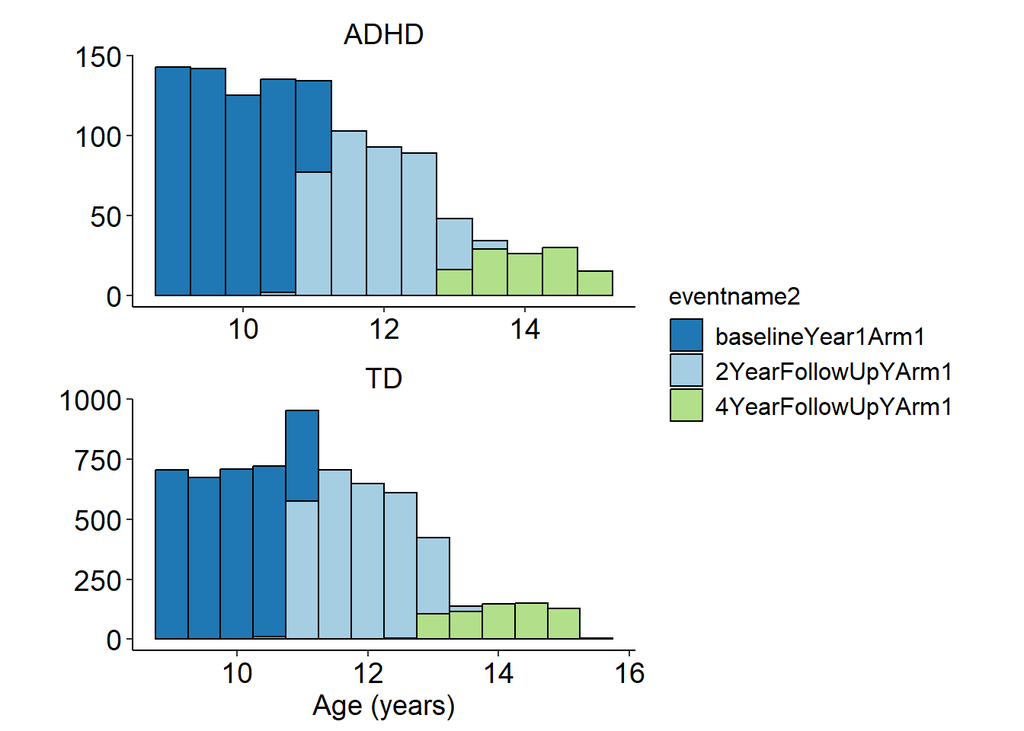

```r
## Plot the age distribution for ADHD and TD
################
fillcolor = brewer.pal(3, "Paired")[c(2, 1, 3)]

ggplot(data = demo_sublist7, aes(age, y = ..count.., fill = eventname2)) +
  geom_histogram(binwidth = 0.5, color = "black", position = "stack",linewidth=0.5) +
  facet_wrap(~if_ADHD, ncol = 1, nrow = 2, scales = "free") +
  labs(x = "Age (years)", y = NULL) +
  #scale_x_continuous(limits = c(9, 16), breaks = c(9,10,11,12,13,14,15,16)) +
  #scale_y_continuous(limits = c(0, 50), breaks = c(0,10, 20,30,40, 50)) +
  scale_fill_manual(values = rep(fillcolor,2))+
  #geom_hline(aes(yintercept = 10), colour = "red", linetype="dashed")+
  theme_classic()+
  theme(panel.background = element_rect(fill="transparent"),
        plot.background = element_rect(fill = "transparent",colour = NA),aspect.ratio = 0.5,
        plot.title = element_text(color = "black", size = 14, hjust = 0.5),
        strip.text = element_text(size = 14, color = "black"),
        strip.background = element_rect(fill = "transparent",colour = NA),
        axis.title = element_text(color = "black", size = 14),axis.line = element_line(linewidth = 0.4),
        axis.ticks = element_line(linewidth = 0.4),
        axis.text = element_text(color = "black", size = 14),
        legend.text = element_text(color = "black", size = 12),
        legend.title = element_text(color = "black", size = 12))
```

```r
ggsave(paste(FigureFolderABCD, '/Fig1_Age_distribution_count_ABCD_ADHDall.tiff', sep = ''),  width = 20, height = 20, units = "cm")
ggsave(paste(FigureFolderABCD, '/Fig1_Age_distribution_count_ABCD_ADHDall.svg', sep = ''), width = 20, height = 20, units = "cm")

## Description for demographic information
ABCD_vars <- c("age", "demo_sex_v2","eventname", "ehi_y_ss_scoreb", "race_ethnicity", "meanFD", "nihtbx_fluidcomp_uncorrected","GENERAL", "siteID","income.adj","adhd_medication", names(mh_p_cbcl)[3:42])
ABCD_tableone <- CreateTableOne(ABCD_vars,strata=c("if_ADHD", "eventname"), data = demo_sublist7, factorVars=c("demo_sex_v2", "ehi_y_ss_scoreb", "race_ethnicity", "siteID", "adhd_medication"), test=F)
invisible(ABCD_tableone <- as.data.frame(print(ABCD_tableone)))
```

```
##                                           Stratified by if_ADHD:eventname
##                                            ADHD:2_year_follow_up_y_arm_1
##   n                                          401
##   age (mean (SD))                          11.92 (0.64)
##   demo_sex_v2 = 2 (%)                        119 ( 29.7)
##   eventname (%)
##      2_year_follow_up_y_arm_1                401 (100.0)
##      4_year_follow_up_y_arm_1                  0 (  0.0)
##      baseline_year_1_arm_1                     0 (  0.0)
##   ehi_y_ss_scoreb (%)
##      1                                       306 ( 76.3)
##      2                                        30 (  7.5)
##      3                                        65 ( 16.2)
##   race_ethnicity (%)
##      White                                   248 ( 61.8)
##      Black                                    32 (  8.0)
##      Hispanic                                 63 ( 15.7)
##      Asian                                     2 (  0.5)
##      Other                                    56 ( 14.0)
##   meanFD (mean (SD))                        0.63 (0.24)
##   nihtbx_fluidcomp_uncorrected (mean (SD)) 84.67 (3.06)
##   GENERAL (mean (SD))                       0.97 (0.67)
##   siteID (%)
##      site1                                     7 (  1.7)
##      site10                                   23 (  5.7)
##      site11                                   22 (  5.5)
##      site12                                   29 (  7.2)
##      site13                                   28 (  7.0)
##      site14                                   17 (  4.2)
##      site15                                    8 (  2.0)
##      site16                                   39 (  9.7)
##      site17                                   19 (  4.7)
##      site18                                   16 (  4.0)
##      site19                                    8 (  2.0)
##      site2                                    23 (  5.7)
##      site20                                   35 (  8.7)
##      site21                                   11 (  2.7)
##      site22                                    0 (  0.0)
##      site3                                    16 (  4.0)
##      site4                                    31 (  7.7)
```

[output cut: 485 more lines]

```
##   cbcl_scr_syn_external_t (mean (SD))      40.56 (7.44)
##   cbcl_scr_syn_totprob_t (mean (SD))       38.80 (8.57)
##   cbcl_scr_dsm5_depress_t (mean (SD))      51.18 (2.77)
##   cbcl_scr_dsm5_anxdisord_t (mean (SD))    51.04 (2.67)
##   cbcl_scr_dsm5_somaticpr_t (mean (SD))    53.76 (5.45)
##   cbcl_scr_dsm5_adhd_t (mean (SD))         50.86 (2.38)
##   cbcl_scr_dsm5_opposit_t (mean (SD))      51.29 (2.52)
##   cbcl_scr_dsm5_conduct_t (mean (SD))      51.10 (2.86)
##   cbcl_scr_07_sct_t (mean (SD))            51.17 (3.05)
##   cbcl_scr_07_ocd_t (mean (SD))            51.30 (3.03)
##   cbcl_scr_07_stress_t (mean (SD))         50.63 (2.22)
##   eventname2 (%)
##      baselineYear1Arm1                      3174 (100.0)
##      2YearFollowUpYArm1                        0 (  0.0)
##      4YearFollowUpYArm1                        0 (  0.0)
```

```r
write.csv(ABCD_tableone, paste0(FigureFolderABCD, '/MRIdemographic_info_ADHDvsTD.csv'))
```